# R Notebook

# Lab 1 - Dowloading R and RStudio - No new code associated with lab

# Lab 2 - Working with Data in R

# Lab 3 - Plotting Sample Data Using ggplot

# Lab 4 - Plotting Real Data Using ggplot

# Lab 5 - Central Limit Theorem

# Lab 6 - Normality and Sample Properties 1

# Lab 7 - Normality and Sample Properties 2

# Lab 8 - Correlation

# Lab 9 - Linear Regression 1

```r
library(tidyverse)
theme_set(theme_bw())
setwd("./Module_5_Linear_Regression/")
load("Module_5_Linear_Regression/framingham.RData")
source("Module_3_CLT-and-Normality/functions.R")
```

```r
head(fhs)
summary(fhs)

# Transforming the data to make it easy to plot with facets
fhs2 <- fhs %>%
  select(-gender) %>%
  pivot_longer(cols = age:glucose,
               names_to = "Metric",
               values_to = "Value")

# Distribution of the variables
ggplot(data = fhs2, mapping = aes(x = Value)) +
  geom_histogram(bins = 30, fill = 'gray', color = 'black') +
  facet_wrap(~ Metric, scales = "free")

# Relationship between the variables
fhs3 <- fhs %>%
  select(-gender) %>%
  pivot_longer(cols = c(age, glucose),
               names_to = "Metric",
               values_to = "Value")

ggplot(data = fhs3, mapping = aes(x = Value, y = sysBP)) +
  geom_point() +
  facet_wrap(~ Metric, scales = "free")
```

```r
# We will review this after the next class
```

```r
# Formula outcome (dependent) ~ predictor (independent), y ~ x

# Model systolic BP as a function of age
sysBPvsAge <- lm(formula = sysBP ~ age, data = fhs)

summary(sysBPvsAge)

# Subset the coefficients table by subsetting the model summary
summary(sysBPvsAge)$coefficients
# sysBPvsAge$coefficients is equivalent to sysBPvsAge[["coefficients"]] and stats::coef(sysBPvsAge)
```

# Lab 13. ANCOVA

```r
library(car)
library(ez)
library(rstatix)
library(pastecs)
library(QuantPsyc)
library(tidyverse)
setwd("./Module_7_ANOVA_GLM")

load("/Users/claireps/GBSC_731_Intro-to-Biostats/Module_7_ANOVA_GLM/ANCOVA_Data.RData")
source("/Users/claireps/GBSC_731_Intro-to-Biostats/Module_3_CLT-and-Normality/functions.R")
```

## Getting to Know Your Data

```r
summary(mouse.mass)

ggplot(data = mouse.mass, mapping = aes(x = group, y = bodyfat)) +
  geom_bar(mapping = aes(fill = group), stat = "summary", fun = "mean", show.legend = FALSE) +
  geom_errorbar(stat = "summary", fun.data = "mean_se", width = 0.3) +
  geom_jitter(width = 0.3) +
  labs(title = "Mean body fat in mice derived from different environments")

ggplot(data = mouse.mass, mapping = aes(x = group, y = leanmass)) +
  geom_bar(mapping = aes(fill = group), stat = "summary", fun = "mean", show.legend = FALSE) +
  geom_errorbar(stat = "summary", fun.data = "mean_se", width = 0.3) +
  geom_jitter(width = 0.3) +
  labs(title = "Mean lean mass in mice derived from different environments")
```

## Test Assumptions

```r
## Homogeneity of Regression Slopes and Linearity ----
ggplot(data = mouse.mass, aes(x = leanmass, y = bodyfat, color = group)) +
  geom_point() +
  geom_smooth(method = 'lm', se = FALSE)


mouse.mass %>%
  filter(group == 'wild') %>%
  lm(bodyfat ~ leanmass, data = .) %>%
  lm.beta()

mouse.mass %>%
  filter(group == 'wild-der') %>%
  lm(bodyfat ~ leanmass, data = .) %>%
  lm.beta()

mouse.mass %>%
  filter(group == 'lab') %>%
  lm(bodyfat ~ leanmass, data = .) %>%
  lm.beta()
```

## Running ANOVA

### Regular ANOVA

```r
mod <- ezANOVA(data = mouse.mass,
               dv = bodyfat,
               between = group,
               wid = idnum,
               type = 3,
               return_aov = TRUE)

mod

# Extracting residuals
residuals <- tibble(group = mouse.mass$group,
                    resid = resid(mod$aov))

# Normality within groups
ggplot(data = residuals, mapping = aes(x = resid)) +
  geom_histogram(bins = 20, fill = 'gray', color = 'black') +
  facet_wrap(~ group, scales = "free")

ggplot(data = residuals, mapping = aes(sample = resid)) +
  geom_qq() +
  geom_qq_line() +
  facet_wrap(~ group, scales = "free")

ggplot(data = residuals, mapping = aes(x = resid)) +
  geom_boxplot() +
  theme(axis.ticks.y = element_blank(),
        axis.text.y = element_blank(),
        panel.grid.major.y = element_blank(),
        panel.grid.minor.y = element_blank()) +
  facet_wrap(~ group, scales = "free")

stat.desc.clean(dataset = residuals, variable = resid, group)
```

### ANCOVA

```r
mod <- anova_test(data = mouse.mass,
                  dv = bodyfat,
                  between = group,
                  covariate = leanmass,
                  wid = idnum,
                  type = 3)

mod

# Extracting residuals
residuals <- tibble(group = mouse.mass$group,
                    resid = resid(attributes(mod)$args$model))

# Normality within groups
ggplot(data = residuals, mapping = aes(x = resid)) +
  geom_histogram(bins = 20, fill = 'gray', color = 'black') +
  facet_wrap(~ group, scales = "free")

ggplot(data = residuals, mapping = aes(sample = resid)) +
  geom_qq() +
  geom_qq_line() +
  facet_wrap(~ group, scales = "free")

ggplot(data = residuals, mapping = aes(x = resid)) +
  geom_boxplot() +
  theme(axis.ticks.y = element_blank(),
        axis.text.y = element_blank(),
        panel.grid.major.y = element_blank(),
        panel.grid.minor.y = element_blank()) +
  facet_wrap(~ group, scales = "free")

stat.desc.clean(dataset = residuals, variable = resid, group)

# Homogeneity of variance - wasn't tested by anova_test
leveneTest(resid ~ group, data = residuals)
```

# Lab 15 - Factorial ANOVA/Two-way independent ANOVA

```r
library(car)
library(ez)
library(pastecs)
library(tidyverse)

theme_set(theme_bw())

setwd("~/GBSC_731_Intro-to-Biostats/Module_8_ANOVA_3")

load("~/GBSC_731_Intro-to-Biostats/Module_8_ANOVA_3/Factorial_ANOVA.RData")

source("~/GBSC_731_Intro-to-Biostats/functions.R")
```

```r
ggplot(data = ad2, mapping = aes(x = drug.tx, y = mmse)) +
  geom_bar(mapping = aes(fill = health), stat = "summary", fun = "mean", show.legend = FALSE) +
  geom_errorbar(stat = "summary", fun.data = "mean_se", width = 0.3) +
  geom_jitter(width = 0.3) +
  facet_wrap(~ health)
```

```r
# Two-way ANOVA with interaction with the stats or car pkg
mod <- stats::aov(mmse ~ health * drug.tx,
  data = ad2)
summary(mod)

car::Anova(mod)

mod <- ez::ezANOVA(data = ad2,
               dv = mmse,
               between = .(health, drug.tx),
               wid = ID,
               type = 3,
               return_aov = TRUE)

mod
```

```r
# Extracting residuals column
residuals <- tibble(group1 = ad2$health,
                    group2 = ad2$drug.tx,
                    resid = resid(mod$aov))

# Normality within groups
ggplot(data = residuals, mapping = aes(x = resid)) +
  geom_histogram(mapping = aes(y = ..density..), bins = 10, fill = 'gray', color = 'black') +
  facet_wrap(~ group1 + group2, scales = "free")
```

```r
ggplot(data = residuals, mapping = aes(sample = resid)) +
  geom_qq() +
  geom_qq_line() +
  facet_wrap(~ group1 + group2, scales = "free")
```

```r
ggplot(data = residuals, mapping = aes(x = resid)) +
  geom_boxplot() +
  theme(axis.ticks.y = element_blank(),
        axis.text.y = element_blank(),
        panel.grid.major.y = element_blank(),
        panel.grid.minor.y = element_blank()) +
  facet_wrap(~ group1 + group2, scales = "free")
```

```r
stat.desc.clean(dataset = residuals, variable = resid, group1, group2)
```

# Lab 19 - Non-Parametric Tests

## Setup

```r
library(car)
library(pastecs)
library(tidyverse)

theme_set(theme_bw())

load("/Users/claireps/GBSC_731_Intro-to-Biostats/Module_11/Non-Parametric-Data.RData")

source("Module_3_CLT-and-Normality/functions.R")
```

## Data Exploration

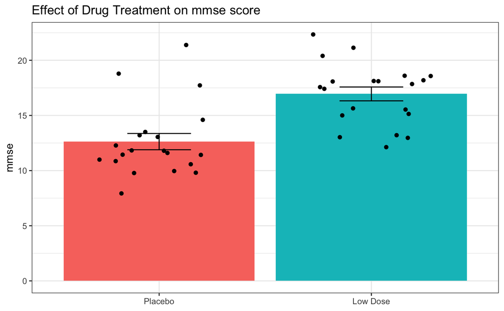

```r
ggplot(data = ad.2vars, mapping = aes(x = drug.tx, y = mmse)) +
  geom_bar(mapping = aes(fill = drug.tx), stat = "summary", fun = "mean", show.legend = FALSE) +
  geom_errorbar(stat = "summary", fun.data = "mean_se", width = 0.3) +
  geom_jitter(width = 0.3) +
  labs(title = "Effect of Drug Treatment on mmse score") +
  theme_bw() +
  theme(axis.title.x = element_blank())
```

### ad.3vars

Appears that High Dose group had an even higher score in the ad.3vars dataset

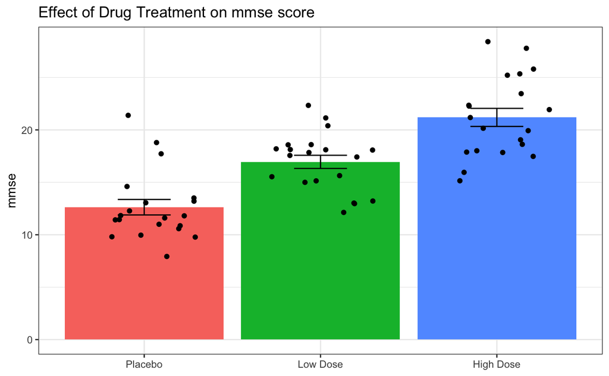

```r
ggplot(data = ad.3vars, mapping = aes(x = drug.tx, y = mmse)) +
  geom_bar(mapping = aes(fill = drug.tx), stat = "summary", fun = "mean", show.legend = FALSE) +
  geom_errorbar(stat = "summary", fun.data = "mean_se", width = 0.3) +
  geom_jitter(width = 0.3) +
  labs(title = "Effect of Drug Treatment on mmse score") +
  theme_bw() +
  theme(axis.title.x = element_blank())
```

### noise.g

Appears that the “none” noise level had a higher score than the “high” noise level in the noise.g dataset

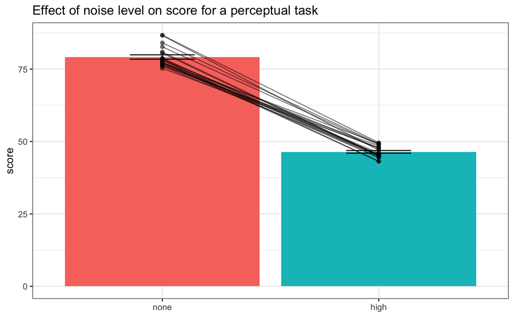

```r
ggplot(data = noise.g, mapping = aes(x = noise.level, y = score)) +
  geom_bar(mapping = aes(fill = noise.level), stat = "summary", fun = "mean", show.legend = FALSE) +
  geom_errorbar(stat = "summary", fun.data = "mean_se", width = 0.3) +
  geom_point(alpha = 0.5) +
  geom_line(mapping = aes(group = ID), alpha = 0.5) +
  labs(title = "Effect of noise level on score for a perceptual task") +
  theme_bw() +
  theme(axis.title.x = element_blank())
```

## Wilcoxon Rank Sum (Mann-Whitney) Test

- Non-parametric equivalent to the **independent t-test**
  - Tests the null hypothesis that the two samples likely derive from the same population (i.e. whether they have similar distributions).
    - Conceptually, tests the *difference in medians* between groups.  
      **Mann-Whitney test** only assumes independence. `wilcox.test()` function takes the same inputs as the `t.test()` function If R version 4.3 or below, use: `wilcox.test(y ~ x, data = dataset, paired = FALSE)` If R version 4.4 or above, use:

```r
wilcox.test(mmse ~ drug.tx, data = ad.2vars)
```

```
    Wilcoxon rank sum exact test

data:  mmse by drug.tx
W = 61, p-value = 7.938e-05
alternative hypothesis: true location shift is not equal to 0
```

> **Do the two samples appear to derive from different populations?** Yes, based on the p-value less than 0.05, we can reject the null hypothesis that the two samples are from the same population and therefore state that there is a significant difference in mmse scores as a function of the drug treatment group.

## Wilcoxon Signed Rank Test

- Non-parametric equivalent to the **paired t-test** - Conceptually, tests if the *median difference* between groups is zero. If R version 4.3 or below, use:  
  `wilcox.test(score ~ noise.level, data = noise.g, paired = TRUE)` If R version 4.4 or above, use:

[output not shown]

## Kruskal-Wallis Rank Sum Test

**Kruskal-Wallis** only assumes independence

```r
kruskal.test(mmse ~ drug.tx, data = ad.3vars)
```

### Post-Hoc Analysis of a Kruskal-Wallis Test

```r
pairwise.wilcox.test(x = ad.3vars$mmse, g = ad.3vars$drug.tx, p.adjust.method = "bonferroni")
```

# Lab 21 - Survival analysis

## Setup

```r
library(survival)
library(survminer)
library(ggfortify)
library(tidyverse)

load("/Users/claireps/GBSC_731_Intro-to-Biostats/Module_11//Ex_Survival.RData")
```

## Data Exploration

Get understand distribution of data

```r
summary(surv1)
```

```
       id               status     starttime  seizuretime      drug
 Min.   : 1.00   No Seizure:23   Min.   :0   Min.   : 0.201   No :20
 1st Qu.:10.75   Seizure   :17   1st Qu.:0   1st Qu.: 6.300   Yes:20
 Median :20.50                   Median :0   Median :18.742
 Mean   :20.50                   Mean   :0   Mean   :18.446
 3rd Qu.:30.25                   3rd Qu.:0   3rd Qu.:33.589
 Max.   :40.00                   Max.   :0   Max.   :35.000
   status.num
 Min.   :1.000
 1st Qu.:1.000
 Median :1.000
 Mean   :1.425
 3rd Qu.:2.000
 Max.   :2.000
```

```r
summary(surv2)
```

```
       id          status     starttime    stoptime        ab40     tau
 Min.   : 1.00   Alive:11   Min.   :0   Min.   : 0.3831   No :20   No :20
 1st Qu.:10.75   Dead :29   1st Qu.:0   1st Qu.: 5.4463   Yes:20   Yes:20
 Median :20.50              Median :0   Median :13.5747
 Mean   :20.50              Mean   :0   Mean   :15.3746
 3rd Qu.:30.25              3rd Qu.:0   3rd Qu.:30.0000
 Max.   :40.00              Max.   :0   Max.   :30.0000
 ab40.tau.intxn   status.num
 neither:10     Min.   :1.000
 ab     :10     1st Qu.:1.000
 tau    :10     Median :2.000
 both   :10     Mean   :1.725
                3rd Qu.:2.000
                Max.   :2.000
```

## Survival Analysis

### Kaplan-Meier Analysis

```r
surv_table <- Surv(time = surv1$seizuretime, event = surv1$status.num)

km.fit <- surv_fit(formula = surv_table ~ drug, data = surv1)
summary(km.fit, times = seq(from = 0, to = 35, by = 5))
```

```
Call: survfit(formula = surv_table ~ drug, data = structure(list(id = c(1,
2, 3, 4, 5, 6, 7, 8, 9, 10, 11, 12, 13, 14, 15, 16, 17, 18, 19,
20, 21, 22, 23, 24, 25, 26, 27, 28, 29, 30, 31, 32, 33, 34, 35,
36, 37, 38, 39, 40), status = structure(c(2L, 2L, 2L, 2L, 2L,
1L, 2L, 2L, 2L, 1L, 1L, 2L, 2L, 1L, 1L, 2L, 1L, 1L, 2L, 2L, 1L,
2L, 1L, 1L, 1L, 1L, 1L, 1L, 1L, 2L, 2L, 1L, 1L, 1L, 1L, 1L, 1L,
2L, 1L, 1L), levels = c("No Seizure", "Seizure"), class = "factor"),
    starttime = c(0, 0, 0, 0, 0, 0, 0, 0, 0, 0, 0, 0, 0, 0, 0,
    0, 0, 0, 0, 0, 0, 0, 0, 0, 0, 0, 0, 0, 0, 0, 0, 0, 0, 0,
    0, 0, 0, 0, 0, 0), seizuretime = c(4.68484938519829, 8.00199755196658,
    0.451036287371672, 0.991761039721032, 26.9492107237754, 35,
    29.9630503759079, 1.70374770432105, 22.8842266097321, 7.82711922154954,
    35, 2.1201994752173, 9.58873433149431, 3.2300856650395, 7.92064965889274,
    5.16635282678698, 15.4646594621864, 22.3449513033702, 22.4927557261188,
    6.4190917609278, 35, 15.7506655849697, 35, 9.6274366330952,
    28.3450122408293, 30.5148402258189, 5.94123283563396, 35,
    12.6082216962699, 0.20098767061449, 21.8540873045226, 21.7326012145873,
    35, 33.1190822471468, 35, 1.34050470991417, 35, 8.5845784013265,
    35, 35), drug = structure(c(1L, 1L, 1L, 1L, 1L, 1L, 1L, 1L,
    1L, 1L, 1L, 1L, 1L, 1L, 1L, 1L, 1L, 1L, 1L, 1L, 2L, 2L, 2L,
    2L, 2L, 2L, 2L, 2L, 2L, 2L, 2L, 2L, 2L, 2L, 2L, 2L, 2L, 2L,
    2L, 2L), levels = c("No", "Yes"), class = "factor"), status.num = c(2,
    2, 2, 2, 2, 1, 2, 2, 2, 1, 1, 2, 2, 1, 1, 2, 1, 1, 2, 2,
    1, 2, 1, 1, 1, 1, 1, 1, 1, 2, 2, 1, 1, 1, 1, 1, 1, 2, 1,
    1)), class = "data.frame", row.names = c(NA, -40L)))

                drug=No
 time n.risk n.event survival std.err lower 95% CI upper 95% CI
    0     20       0    1.000  0.0000       1.0000        1.000
    5     14       5    0.747  0.0981       0.5772        0.966
   10      8       4    0.512  0.1192       0.3245        0.808
   15      8       0    0.512  0.1192       0.3245        0.808
   20      7       0    0.512  0.1192       0.3245        0.808
   25      4       2    0.341  0.1266       0.1650        0.706
   30      2       2    0.171  0.1062       0.0504        0.578
   35      2       0    0.171  0.1062       0.0504        0.578

                drug=Yes
 time n.risk n.event survival std.err lower 95% CI upper 95% CI
    0     20       0    1.000  0.0000        1.000            1
    5     18       1    0.950  0.0487        0.859            1
   10     15       1    0.894  0.0710        0.765            1
   15     14       0    0.894  0.0710        0.765            1
   20     13       1    0.830  0.0902        0.671            1
   25     11       1    0.761  0.1059        0.579            1
   30     10       0    0.761  0.1059        0.579            1
   35      8       0    0.761  0.1059        0.579            1
```

#### Plot Kaplan-Meier Survival Curve

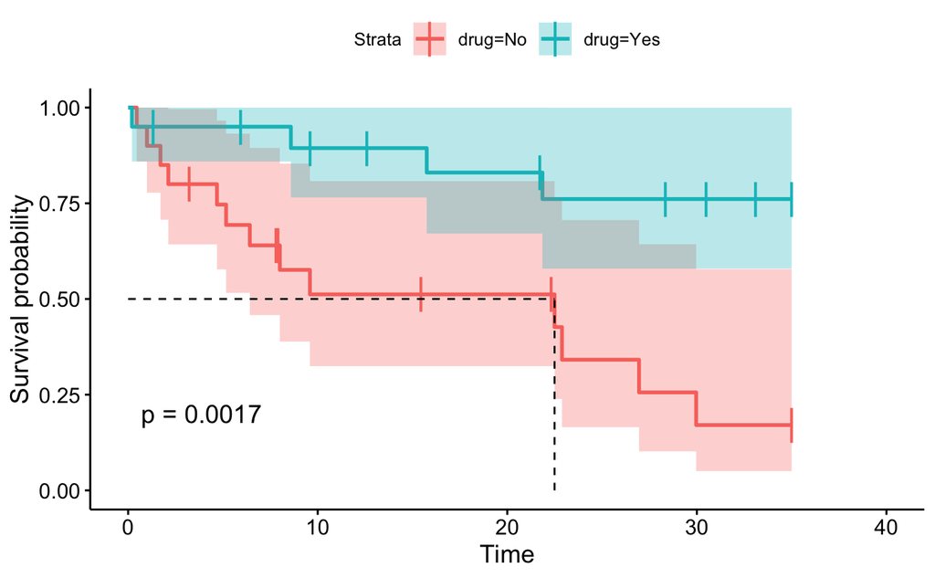

```r
ggsurvplot(fit = km.fit, data = surv1, # provide the model and the data
           conf.int = TRUE, # plot shaded confidence intervals
           surv.median.line = 'hv',  # plot horizontal and vertical lines at the median for each curve
           pval = TRUE, # plot the overall p-value
           censor.shape = 124, # change the shape for the censor mark
           censor.size = 7) # change the size for the censor mark
```

**Test** whether there is a **difference in survival** - use `survdiff` function

```r
survdiff(formula = surv_table ~ drug, data = surv1)
```

```
Call:
survdiff(formula = surv_table ~ drug, data = surv1)

          N Observed Expected (O-E)^2/E (O-E)^2/V
drug=No  20       13     6.77      5.75      9.84
drug=Yes 20        4    10.23      3.80      9.84

 Chisq= 9.8  on 1 degrees of freedom, p= 0.002
```

Time at which **50%** of the group remains unaffected for **both** drug treatment levels - use `surv_median` function

```r
surv_median(fit = km.fit)
```

| strata | median | lower | upper |
| --- | --- | --- | --- |
| drug=No | 22.49276 | 6.419092 | NA |
| drug=Yes | NA | NA | NA |

### Cox Regression Analysis

Look at the effect of expression of two genes (a-beta and tau) on time-to-death in mice using the `surv2` dataset.

#### Assumptions

- Independence
- Proportional hazards

Pass in the `ab40.tau.intxn` variable that describes the *interaction* of `tau` and `ab40`. This has 4 groups that describe mice that express ab40 only, tau only, neither, or both in a single column. surv_fit does not like having interaction terms in the formula, so the interaction was created as a separate variable.

```r
surv_table <- Surv(time = surv2$stoptime, event = surv2$status.num)

surv.curv <- surv_fit(formula = surv_table ~ ab40.tau.intxn, data = surv2)

ggsurvplot(fit = surv.curv, data = surv2,
           conf.int = FALSE,
           censor.shape = 124,
           censor.size = 7,
           legend.labs = c('neither', 'ab', 'tau', 'both'))
```

Create log minus log plot - Uses same `ggsurvplot` function call, but adds `fun = 'cloglog'` and `xlim = c(0.5,30)`. - `cloglog` transforms both axes and excludes 0 from the x-axis since 0 cannot be log transformed. - Why code limits the values on the x-axis to be from 0.5 to 30 (our maximum time in our experiment).

```r
ggsurvplot(surv.curv, data = surv2,
           conf.int = FALSE,
           censor.shape = 124,
           censor.size = 7,
           legend.labs = c('neither', 'ab', 'tau', 'both'),
           fun = 'cloglog',
           xlim = c(0.5, 30))
```

#### Statistical Test of Proportional Hazards

To test the proportional hazards assumption statistically:

1. First, create a Cox model using the `coxph` function. - This function behaves exactly like the `surv_fit` function from above, but the right hand side will have ab40, tau, and their interaction (denoted with the * function).

```r
cox.m <- coxph(formula = surv_table ~ ab40*tau, data = surv2)
```

2. For the statistical test, pass in the `cox.m` object into the `cox.zph` function.

```r
cox.zph(cox.m)
```

##### Running test

View model summary of the cox model

```r
summary(cox.m)
```

# Lab 22 - Random Forests

## Setup

```r
require(MASS)
```

## Training

```r
# Randomly sample 80% of the observation indices from our data set to determine our training set
train_vec <- sort(sample(1:nrow(Boston), floor(nrow(Boston) * 0.8)))
# Select the remaining sample indices for our testing set
test_vec <- setdiff(1:nrow(Boston), train_vec)

# Subset the Boston data set using our training and testing data indices
Boston_train <- Boston[train_vec,]
Boston_test <- Boston[test_vec,]
```

## Basic Regression Tree

```r
basic_Boston_tree <- tree::tree(medv ~ .,
                                data = Boston_train, #Could also use `data = Boston, subset = train_vec`
                                split = "deviance")   #Deviance is the default loss function, gini index is the other option
summary(basic_Boston_tree)
```

```
Regression tree:
tree::tree(formula = medv ~ ., data = Boston_train, split = "deviance")
Variables actually used in tree construction:
[1] "rm"    "lstat" "dis"   "crim"
Number of terminal nodes:  8
Residual mean deviance:  16.13 = 6387 / 396
Distribution of residuals:
     Min.   1st Qu.    Median      Mean   3rd Qu.      Max.
-23.04000  -1.94900  -0.04784   0.00000   2.05700  16.90000
```

### Visualize Basic Regression Tree

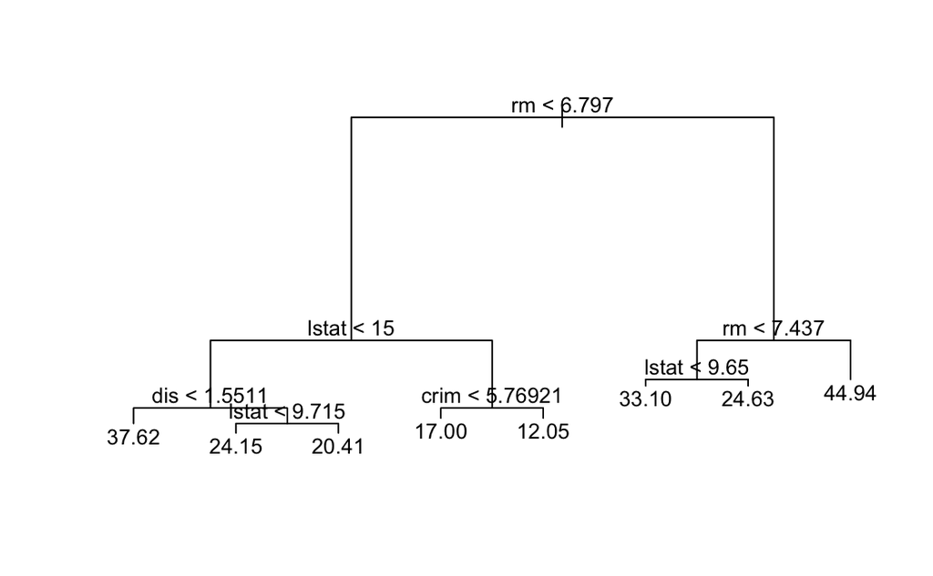

```r
plot(basic_Boston_tree); text(basic_Boston_tree)
```

### Tree Pruning

#### Determine/optimize the number of nodes

Plot shows after six nodes, we see a fairly minimal step size in the deviance. This means the first six nodes are the most important for redicing model deviance. Let’s prune our tree, and use this as our pruning criteria as the best argument.

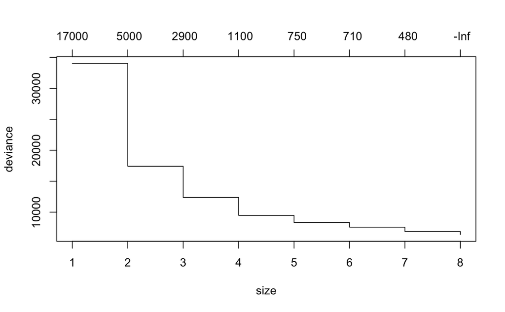

```r
prune_Boston_tree <- prune.tree(basic_Boston_tree)
plot(prune_Boston_tree)
```

#### Plot the Pruned Tree

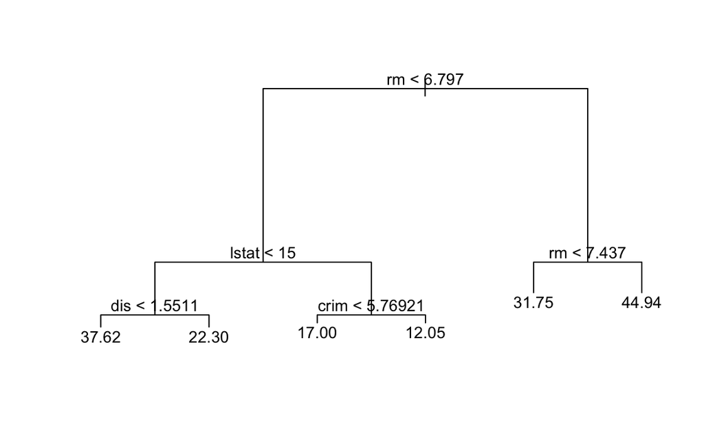

```r
prune_Boston_tree <- prune.tree(basic_Boston_tree, best = 6)
plot(prune_Boston_tree)
text(prune_Boston_tree, pretty = 0)
```

### Compare Deviance between Pruned and Unpruned Trees

Note: Can also do cross-validation using cv.tree() - not shown in labs

```r
summary(basic_Boston_tree)
```

```
Regression tree:
tree::tree(formula = medv ~ ., data = Boston_train, split = "deviance")
Variables actually used in tree construction:
[1] "rm"    "lstat" "dis"   "crim"
Number of terminal nodes:  8
Residual mean deviance:  16.13 = 6387 / 396
Distribution of residuals:
     Min.   1st Qu.    Median      Mean   3rd Qu.      Max.
-23.04000  -1.94900  -0.04784   0.00000   2.05700  16.90000
```

```r
summary(prune_Boston_tree)
```

```
Regression tree:
snip.tree(tree = basic_Boston_tree, nodes = c(6L, 9L))
Variables actually used in tree construction:
[1] "rm"    "lstat" "dis"   "crim"
Number of terminal nodes:  6
Residual mean deviance:  19.04 = 7577 / 398
Distribution of residuals:
      Min.    1st Qu.     Median       Mean    3rd Qu.       Max.
-23.040000  -2.415000  -0.000934   0.000000   2.297000  18.250000
```

### Prediction

```r
basic_Boston_pred <- predict(basic_Boston_tree, newdata = Boston_test)
```

# Plot Relationship between Predicted vs. Real Values

If predictions match the true values, then points should follow this line closely.

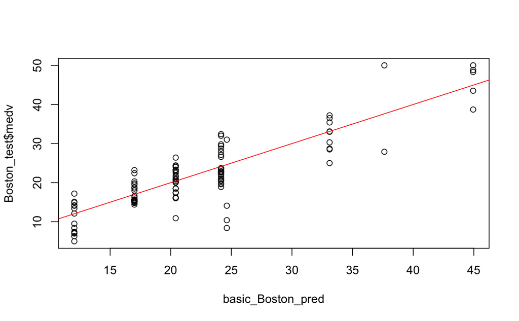

```r
plot(basic_Boston_pred, Boston_test$medv)
abline(0,1, col="red")
```

```r
basic_MSE <- mean((basic_Boston_pred - Boston_test$medv)^2)
sqrt(basic_MSE)
```

```
[1] 4.553685
```

## Random Forest

Note: We can perform bagging (wherein we build FULL trees with all covariates) by setting mtry to the number of predictors, but we won’t bother with that here.

```r
Boston_forest <- randomForest(medv ~ ., data = Boston_train,
                              ntree = 500,  #The number of trees to grow in your forest, default is 500
                              #mtry = ...,  #The number of predictors to sample, determined heuristically by default as 1/3*(p) (reg) or sqrt(p) (classification)
                              importance = TRUE,  #We can also determine importance of variables
                              )
Boston_forest
```

```
Call:
 randomForest(formula = medv ~ ., data = Boston_train, ntree = 500,      importance = TRUE, )
               Type of random forest: regression
                     Number of trees: 500
No. of variables tried at each split: 4

          Mean of squared residuals: 10.3336
                    % Var explained: 87.72
```

### Compare Random Forest to a Single Tree - Predict on the test set

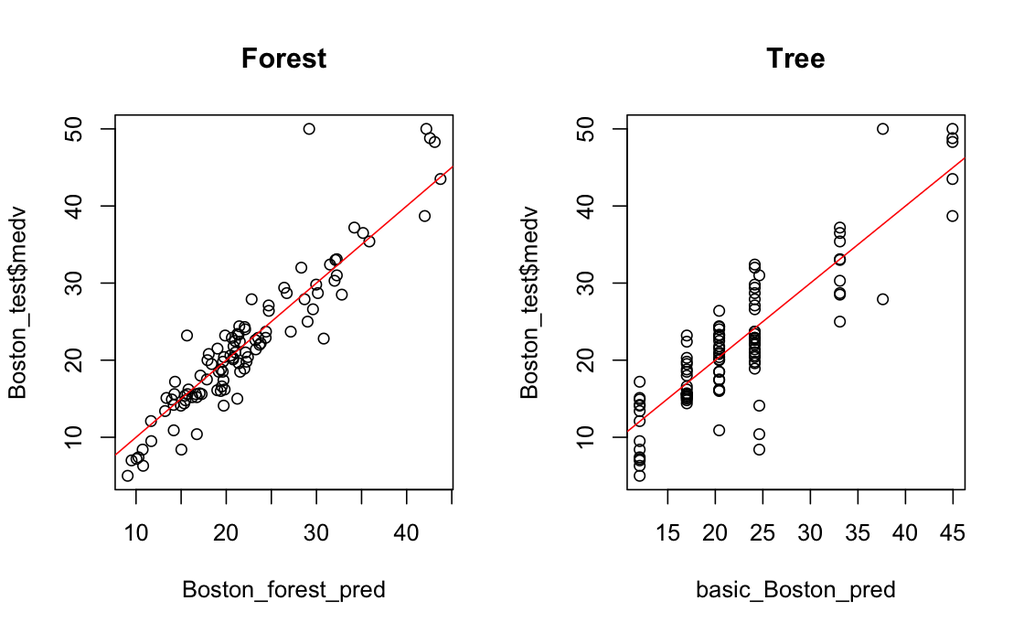

```r
Boston_forest_pred <- predict(Boston_forest, newdata = Boston_test)
par(mfrow = c(1,2))
plot(Boston_forest_pred, Boston_test$medv, main = "Forest"); abline(0,1, col="red")
plot(basic_Boston_pred, Boston_test$medv, main = "Tree"); abline(0,1, col="red")
```

# Lab 23 - Clustering

## Setup

```r
set.seed(123456)
```

### Make First Dataset

```r
X1 <- matrix(rnorm(50*2), ncol = 2)
X1[1:25 ,1] <- X1[1:25 ,1] + 3
X1[1:25 ,2] <- X1[1:25 ,2] - 4
```

### Make Second Dataset

```r
X2 <- matrix(rnorm(100*2), ncol = 2)
X2[1:20 ,1] <- X2[1:20 ,1] + 3
X2[1:20 ,2] <- X2[1:20 ,2] - 4
X2[71:90 ,1] <- X2[81:90 ,1] - 1
X2[71:90 ,2] <- X2[81:90 ,2] + 1
X2[91:100 ,1] <- X2[91:100 ,1] - 6
X2[91:100 ,2] <- X2[91:100 ,2] + 5
```

## K-means Clustering

```r
X1_km_2 <- kmeans(X1,
                 centers = 2,  #K, the number of centers
                 nstart = 20   #The number of random sets, defaults to 1 but should always be made bigger
                 )
```

### Check Cluster Assignments

```r
X1_km_2$cluster
```

```
 [1] 1 1 1 1 1 1 1 1 1 1 1 1 1 1 1 1 1 1 1 1 1 1 1 1 1 2 2 2 2 2 2 2 2 2 2 2 2 2 2 2 2 2 2 2 2 2 2 2 2 2
```

### Plot Clusters

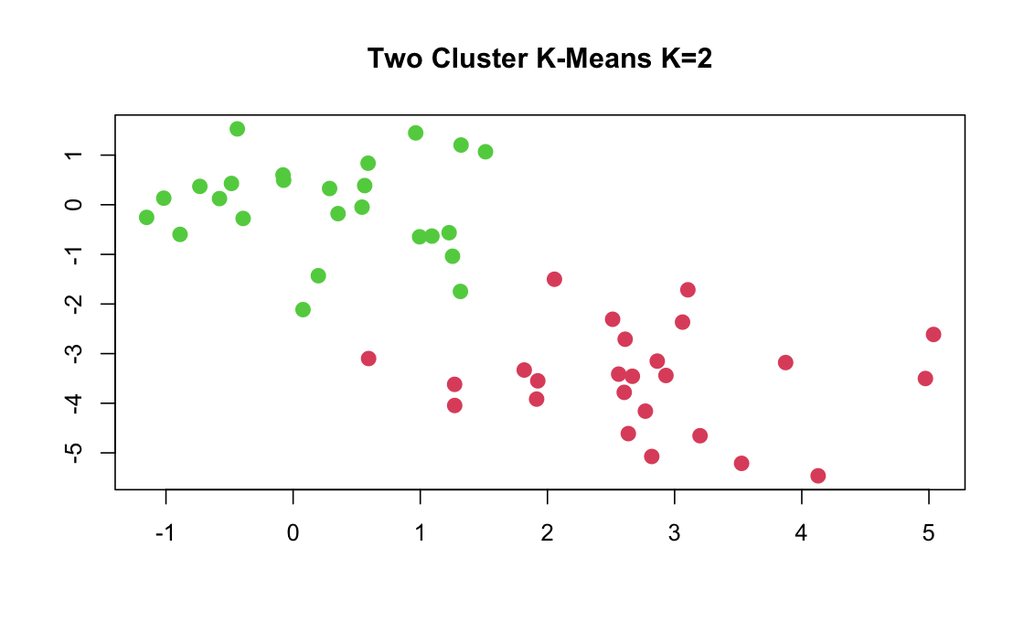

```r
plot(X1, col = (X1_km_2$cluster + 1),
     main="Two Cluster K-Means K=2",
     xlab = "", ylab = "", pch = 20, cex = 2)
```

### Compare Number of Centers

```r
X2_km_2 <- kmeans(X2, center = 2, nstart = 20)
X2_km_3 <- kmeans(X2, center = 3, nstart = 20)
X2_km_4 <- kmeans(X2, center = 4, nstart = 20)


#Comparing all three side-by-side
par(mfrow = c(1,3))
plot(X2, col = (X2_km_2$cluster + 1),
     main="Four Cluster K-Means K=2",
     xlab = "", ylab = "", pch = 20, cex = 2)
plot(X2, col = (X2_km_3$cluster + 1),
     main="Four Cluster K-Means K=3",
     xlab = "", ylab = "", pch = 20, cex = 2)
```

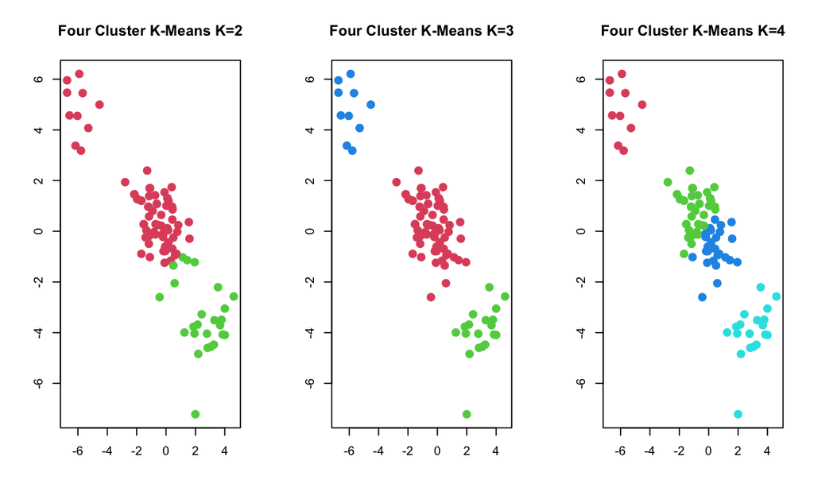

```r
plot(X2, col = (X2_km_4$cluster + 1),
     main="Four Cluster K-Means K=4",
     xlab = "", ylab = "", pch = 20, cex = 2)
```

#### Visualize the output of one of the clusterings

```r
par(mfrow = c(1,1))
table(X2_km_4$cluster)
```

```
 1  2  3  4
10 42 29 19
```

Small within-cluster sum of squares indicates tighter clusters